# Module-2

Sankalp Biswal

2023-11-14

## 1.Importing Libraries

```r
library(pacman)
library(ggplot2)
library(tidyverse)
library(janitor)
library(lubridate)
library(gmodels)
library(plotly)
library(reshape2)
library(dplyr)
library(purrr)
library(knitr)
library(kableExtra)
```

## 2.Importing dataset

- Selecting variables of interest

```r
property_dataset <- read.csv("fy2023-property-assessment-data.csv")

property_subset <- subset(property_dataset,select = c(CITY,LU,LU_DESC,BLDG_TYPE,LAND_SF,GROSS_AREA,BLDG_VALUE,LAND_VALUE,TOTAL_VALUE,GROSS_TAX,YR_BUILT,YR_REMODEL,ROOF_STRUCTURE,BED_RMS,FULL_BTH,KITCHENS,TT_RMS,RES_FLOOR,OVERALL_COND,HEAT_TYPE,AC_TYPE,PROP_VIEW,NUM_PARKING,FIREPLACES,ZIP_CODE))
```

## 3. Data Cleaning

- We’ll clean the data using `IQR()` and replace the out of bound values by ‘NA’ and then impute ‘NA’ values by **Median** so that we can preserve the original sample size.

```r
clean_numeric_columns <- function(x) {
  # Remove outliers based on IQR
  q1 <- quantile(x, 0.25, na.rm = TRUE)
  q3 <- quantile(x, 0.75, na.rm = TRUE)
  iqr_value <- IQR(x, na.rm = TRUE)

  lower_bound <- q1 - 1.5 * iqr_value
  upper_bound <- q3 + 1.5 * iqr_value

  x_outliers_removed <- ifelse(x < lower_bound | x > upper_bound, NA, x)

  # Impute missing values with the median
  x_cleaned <- ifelse(is.na(x_outliers_removed), median(x, na.rm = TRUE), x_outliers_removed)

  return(x_cleaned)
}

# Clean all numeric columns in the dataset
property_subset_clean <- property_subset %>%
  mutate(across(where(is.numeric), clean_numeric_columns))

# Remove rows with any NA values after cleaning
property_subset_clean <- na.omit(property_subset_clean)

property_subset_clean <- property_subset_clean %>%
  mutate(CITY = ifelse(CITY == "" | is.na(CITY), "Unknown", CITY))

property_subset_clean <- property_subset_clean %>%
  mutate(OVERALL_COND = ifelse(OVERALL_COND == "" | is.na(OVERALL_COND), "Unknown", OVERALL_COND))

property_subset_clean <- property_subset_clean %>%
  mutate(PROP_VIEW = ifelse(PROP_VIEW == "" | is.na(PROP_VIEW), "Unknown", PROP_VIEW))

property_subset_clean <- property_subset_clean %>%
  mutate(AC_TYPE = ifelse(AC_TYPE == "" | is.na(AC_TYPE), "Unknown", AC_TYPE))
```

## 4. Tabulations

### a) Group statistics by City

- Grouping dataset by **cities** and generating statistics like **Mean**, **sd**, **min**, **max**, and **count**

```r
city_stats <- property_subset_clean %>%
  group_by(CITY) %>%
  summarise(across(where(is.numeric), list(
    mean_value = ~mean(., na.rm = TRUE),
    sd_value = ~sd(., na.rm = TRUE),
    min_value = ~min(., na.rm = TRUE),
    max_value = ~max(., na.rm = TRUE),
    count = ~sum(!is.na(.))
  ), .names = "{col}_{fn}"))

kable(city_stats, format = "html",
      caption = "Grouping Statistics by CITY",
      align ="cccc",
     )%>%
  kable_styling(full_width = FALSE)
```

Grouping Statistics by CITY

| CITY | LAND_SF_mean_value | LAND_SF_sd_value | LAND_SF_min_value | LAND_SF_max_value | LAND_SF_count | GROSS_AREA_mean_value | GROSS_AREA_sd_value | GROSS_AREA_min_value | GROSS_AREA_max_value | GROSS_AREA_count | BLDG_VALUE_mean_value | BLDG_VALUE_sd_value | BLDG_VALUE_min_value | BLDG_VALUE_max_value | BLDG_VALUE_count | LAND_VALUE_mean_value | LAND_VALUE_sd_value | LAND_VALUE_min_value | LAND_VALUE_max_value | LAND_VALUE_count | TOTAL_VALUE_mean_value | TOTAL_VALUE_sd_value | TOTAL_VALUE_min_value | TOTAL_VALUE_max_value | TOTAL_VALUE_count | GROSS_TAX_mean_value | GROSS_TAX_sd_value | GROSS_TAX_min_value | GROSS_TAX_max_value | … |
| --- | --- | --- | --- | --- | --- | --- | --- | --- | --- | --- | --- | --- | --- | --- | --- | --- | --- | --- | --- | --- | --- | --- | --- | --- | --- | --- | --- | --- | --- | --- |
| ALLSTON | 2509.162 | 2197.625 | 100 | 10388 | 4423 | 2275.059 | 1823.355 | 3 | 8604 | 4423 | 520738.6 | 279717.9 | 0 | 1413700 | 4423 | 104565.70 | 157528.91 | 0 | 561236 | 4423 | 635154.2 | 376256.4 | 0 | 1714500 | 4423 | 6680.372 | 4008.301 | 0.000 | 18453.467 | … |
| BOSTON | 1491.213 | 1221.085 | 101 | 10420 | 47104 | 1682.292 | 1249.280 | 25 | 8640 | 47104 | 543121.5 | 347347.8 | 0 | 1414100 | 47104 | 16799.13 | 79888.56 | 0 | 561600 | 47104 | 623043.3 | 395098.0 | 0 | 1715700 | 47104 | 6447.484 | 4374.329 | 0.000 | 18454.537 | … |
| BRIGHTON | 2543.282 | 2338.322 | 113 | 10405 | 11870 | 2181.034 | 1799.889 | 100 | 8592 | 11870 | 484036.3 | 255687.5 | 0 | 1413700 | 11870 | 107595.26 | 154279.18 | 0 | 562500 | 11870 | 594385.0 | 358777.3 | 0 | 1715200 | 11870 | 6280.716 | 3906.149 | 0.000 | 18452.390 | … |
| BROOKLINE | 4048.708 | 1706.775 | 881 | 7000 | 24 | 4449.167 | 2075.870 | 881 | 7260 | 24 | 691437.5 | 327954.3 | 0 | 1201800 | 24 | 310387.50 | 201782.56 | 0 | 518100 | 24 | 983700.0 | 506916.4 | 0 | 1688100 | 24 | 9999.924 | 5828.865 | 0.000 | 18130.190 | … |
| CHARLESTOWN | 1433.702 | 1075.834 | 106 | 10386 | 7230 | 1846.108 | 1081.240 | 324 | 8616 | 7230 | 555500.1 | 371028.2 | 0 | 1413900 | 7230 | 78861.19 | 145839.93 | 0 | 562500 | 7230 | 653957.4 | 431568.4 | 0 | 1714300 | 7230 | 6839.392 | 4737.971 | 0.000 | 18438.430 | … |
| CHESTNUT HILL | 1834.948 | 1950.346 | 223 | 9944 | 1017 | 1504.457 | 1255.644 | 401 | 7654 | 1017 | 419061.6 | 235049.3 | 0 | 1409900 | 1017 | 33939.33 | 91950.68 | 0 | 553400 | 1017 | 520106.3 | 364876.0 | 0 | 1657900 | 1017 | 5546.289 | 3924.105 | 0.000 | 17805.847 | … |
| DEDHAM | 4680.667 | 2785.488 | 1330 | 8228 | 6 | 2721.000 | 1077.993 | 2125 | 4900 | 6 | 316366.7 | 304932.0 | 0 | 822800 | 6 | 166383.33 | 120591.03 | 12700 | 281400 | 6 | 482750.0 | 404693.5 | 12700 | 1058400 | 6 | 5184.733 | 4346.408 | 136.400 | 11367.217 | … |
| DORCHESTER | 3517.647 | 2049.885 | 100 | 10423 | 29212 | 3386.669 | 1896.100 | 100 | 8640 | 29212 | 425904.6 | 261471.4 | 0 | 1411800 | 29212 | 138801.47 | 115702.28 | 0 | 562400 | 29212 | 570512.4 | 326680.5 | 0 | 1713200 | 29212 | 6007.576 | 3652.608 | 0.000 | 18451.320 | … |
| EAST BOSTON | 2142.705 | 1625.491 | 100 | 10358 | 9951 | 2593.768 | 1594.873 | 100 | 8640 | 9951 | 462957.1 | 272373.6 | 0 | 1413300 | 9951 | 114900.59 | 118144.26 | 0 | 558500 | 9951 | 587681.2 | 334280.7 | 0 | 1714600 | 9951 | 6263.397 | 3750.557 | 0.000 | 18411.890 | … |
| HYDE PARK | 4881.729 | 2392.979 | 100 | 10422 | 9207 | 2828.298 | 1232.040 | 100 | 8640 | 9207 | 314932.1 | 175887.4 | 0 | 1412700 | 9207 | 156064.95 | 92243.90 | 0 | 558000 | 9207 | 477775.1 | 228762.2 | 0 | 1697900 | 9207 | 5056.070 | 2586.822 | 0.000 | 18285.410 | … |
| JAMAICA PLAIN | 2882.166 | 2176.017 | 100 | 10414 | 12104 | 2477.407 | 1674.741 | 100 | 8619 | 12104 | 520806.5 | 329397.4 | 0 | 1413700 | 12104 | 111333.38 | 162693.52 | 0 | 562500 | 12104 | 637322.9 | 420380.3 | 0 | 1715000 | 12104 | 6753.021 | 4621.264 | 0.000 | 18450.770 | … |
| MATTAPAN | 4528.211 | 1927.585 | 115 | 10416 | 4847 | 3276.548 | 1595.947 | 4 | 8600 | 4847 | 333446.9 | 204239.3 | 0 | 1413000 | 4847 | 146725.55 | 85171.72 | 0 | 549200 | 4847 | 483808.0 | 257296.4 | 0 | 1704500 | 4847 | 5083.583 | 2854.012 | 0.000 | 18154.610 | … |
| NEWTON | 5090.000 | NA | 5090 | 5090 | 1 | 3825.000 | NA | 3825 | 3825 | 1 | 414400.0 | NA | 414400 | 414400 | 1 | 215100.00 | NA | 215100 | 215100 | 1 | 629500.0 | NA | 629500 | 629500 | 1 | 6760.827 | NA | 6760.827 | 6760.827 | … |
| READVILLE | 5079.500 | 4335.272 | 2014 | 8145 | 2 | 3556.500 | 2024.447 | 2125 | 4988 | 2 | 568500.0 | 112147.1 | 489200 | 647800 | 2 | 91000.00 | 128693.43 | 0 | 182000 | 2 | 719700.0 | 155704.9 | 609600 | 829800 | 2 | 3230.594 | 4568.749 | 0.000 | 6461.187 | … |
| ROSLINDALE | 4113.130 | 2230.198 | 113 | 10402 | 9210 | 2788.217 | 1407.415 | 120 | 8568 | 9210 | 402995.8 | 215551.9 | 0 | 1399800 | 9210 | 142493.38 | 112938.21 | 0 | 545300 | 9210 | 548832.4 | 280573.1 | 0 | 1703806 | 9210 | 5870.318 | 3114.817 | 0.000 | 18273.070 | … |
| ROXBURY | 2917.603 | 1969.704 | 107 | 10421 | 6168 | 2875.107 | 1639.096 | 42 | 8616 | 6168 | 352143.0 | 279729.9 | 0 | 1413961 | 6168 | 103321.71 | 109489.80 | 0 | 561800 | 6168 | 468716.3 | 337425.4 | 0 | 1713100 | 6168 | 4743.391 | 3741.367 | 0.000 | 18299.890 | … |
| ROXBURY CROSSING | 2532.479 | 1772.362 | 185 | 10412 | 1832 | 2980.621 | 1860.585 | 100 | 8642 | 1832 | 511600.5 | 383344.3 | 0 | 1414100 | 1832 | 156740.27 | 187520.89 | 0 | 561700 | 1832 | 628109.6 | 429977.7 | 0 | 1713743 | 1832 | 6234.123 | 4929.640 | 0.000 | 18434.140 | … |
| SOUTH BOSTON | 1623.014 | 1203.471 | 100 | 10418 | 15439 | 1923.238 | 1232.958 | 90 | 8625 | 15439 | 540599.4 | 366421.9 | 0 | 1410600 | 15439 | 72626.13 | 132886.70 | 0 | 562400 | 15439 | 618473.1 | 420574.7 | 0 | 1715800 | 15439 | 6586.627 | 4566.800 | 0.000 | 18452.397 | … |
| Unknown | 4562.600 | 3430.438 | 2014 | 8320 | 5 | 2125.000 | 0.000 | 2125 | 2125 | 5 | 332760.0 | 293463.8 | 7500 | 646900 | 5 | 0.00 | 0.00 | 0 | 0 | 5 | 501340.0 | 263423.7 | 31000 | 646900 | 5 | 7136.398 | 5603.741 | 332.940 | 15965.490 | … |
| WEST ROXBURY | 4591.690 | 2337.698 | 110 | 10416 | 10975 | 2771.081 | 1200.629 | 60 | 8500 | 10975 | 391766.7 | 229428.4 | 0 | 1414100 | 10975 | 179690.70 | 119162.34 | 0 | 561500 | 10975 | 579196.8 | 310047.0 | 0 | 1713000 | 10975 | 6118.703 | 3420.295 | 0.000 | 18309.547 | … |

### b) Group statistics by overall condition of the parcel

- Grouping dataset by **overall condition** and generating statistics like **Mean**, **sd**, **min**, **max**, and **count**

```r
overall_cond_stats <- property_subset_clean %>%
  group_by(OVERALL_COND) %>%
  summarise(across(where(is.numeric), list(
    mean_value = ~mean(., na.rm = TRUE),
    sd_value = ~sd(., na.rm = TRUE),
    min_value = ~min(., na.rm = TRUE),
    max_value = ~max(., na.rm = TRUE),
    count = ~sum(!is.na(.))
  ), .names = "{col}_{fn}"))

kable(overall_cond_stats, format = "html",
      caption = "Grouping Statistics by OVERALL CONDITION",
      align ="cccc",
     )%>%
  kable_styling(full_width = FALSE)
```

Grouping Statistics by OVERALL CONDITION

| OVERALL_COND | LAND_SF_mean_value | LAND_SF_sd_value | LAND_SF_min_value | LAND_SF_max_value | LAND_SF_count | GROSS_AREA_mean_value | GROSS_AREA_sd_value | GROSS_AREA_min_value | GROSS_AREA_max_value | GROSS_AREA_count | BLDG_VALUE_mean_value | BLDG_VALUE_sd_value | BLDG_VALUE_min_value | BLDG_VALUE_max_value | BLDG_VALUE_count | LAND_VALUE_mean_value | LAND_VALUE_sd_value | LAND_VALUE_min_value | LAND_VALUE_max_value | LAND_VALUE_count | TOTAL_VALUE_mean_value | TOTAL_VALUE_sd_value | TOTAL_VALUE_min_value | TOTAL_VALUE_max_value | TOTAL_VALUE_count | GROSS_TAX_mean_value | GROSS_TAX_sd_value | GROSS_TAX_min_value | GROSS_TAX_max_value | … |
| --- | --- | --- | --- | --- | --- | --- | --- | --- | --- | --- | --- | --- | --- | --- | --- | --- | --- | --- | --- | --- | --- | --- | --- | --- | --- | --- | --- | --- | --- | --- |
| A - Average | 2758.275 | 2190.346 | 100 | 10423 | 131741 | 2438.416 | 1631.0123 | 25 | 8640 | 131741 | 444729.9 | 302081.6 | 0 | 1414100 | 131741 | 101552.620 | 128235.13 | 0 | 562500 | 131741 | 567249.2 | 358447.7 | 0 | 1715800 | 131741 | 5973.897 | 3954.496 | 0.000 | 18452.397 | … |
| AVG - Default - Average | 2014.000 | NA | 2014 | 2014 | 1 | 2125.000 | NA | 2125 | 2125 | 1 | 489200.0 | NA | 489200 | 489200 | 1 | 0.000 | NA | 0 | 0 | 1 | 609600.0 | NA | 609600 | 609600 | 1 | 6461.187 | NA | 6461.187 | 6461.187 | … |
| E - Excellent | 1639.082 | 1145.935 | 371 | 10035 | 1444 | 2315.499 | 1727.5219 | 371 | 8589 | 1444 | 586061.0 | 283477.3 | 0 | 1404600 | 1444 | 25874.584 | 97947.03 | 0 | 559400 | 1444 | 724027.1 | 348703.8 | 0 | 1715000 | 1444 | 7738.659 | 3771.185 | 0.000 | 18429.840 | … |
| EX - Excellent | 1877.399 | 1032.000 | 405 | 10191 | 1254 | 1885.685 | 987.8651 | 100 | 8360 | 1254 | 566689.3 | 347166.6 | 0 | 1411900 | 1254 | 1904.760 | 30204.91 | 0 | 532700 | 1254 | 709466.8 | 422655.0 | 0 | 1712000 | 1254 | 7237.259 | 4912.005 | 0.000 | 18438.427 | … |
| F - Fair | 3489.773 | 2302.203 | 270 | 10330 | 1007 | 3582.673 | 1778.7875 | 368 | 8594 | 1007 | 419563.2 | 282397.6 | 0 | 1412700 | 1007 | 212651.772 | 142644.22 | 0 | 559800 | 1007 | 645477.3 | 329550.4 | 0 | 1715300 | 1007 | 6788.721 | 3665.539 | 0.000 | 18454.537 | … |
| G - Good | 2772.093 | 2188.011 | 170 | 10420 | 34208 | 2603.134 | 1699.1786 | 3 | 8642 | 34208 | 590008.1 | 311407.6 | 0 | 1414100 | 34208 | 100697.998 | 140547.78 | 0 | 562500 | 34208 | 705535.6 | 378466.6 | 0 | 1715800 | 34208 | 7334.464 | 4232.177 | 0.000 | 18453.467 | … |
| P - Poor | 3327.874 | 2458.062 | 313 | 10126 | 95 | 3183.011 | 1649.9348 | 341 | 7880 | 95 | 358078.8 | 295645.5 | 0 | 1342000 | 95 | 157269.232 | 151443.12 | 0 | 557600 | 95 | 532854.4 | 261234.3 | 0 | 1349300 | 95 | 5526.987 | 3549.582 | 0.000 | 17784.410 | … |
| US - Unsound | 3010.550 | 2163.252 | 1316 | 8526 | 20 | 3622.850 | 1912.3276 | 1400 | 7380 | 20 | 441460.6 | 393495.9 | 1300 | 1411300 | 20 | 172745.000 | 177121.19 | 0 | 508000 | 20 | 693591.8 | 391387.4 | 139000 | 1674700 | 20 | 6547.844 | 4488.558 | 0.000 | 15694.010 | … |
| Unknown | 1656.248 | 1489.310 | 106 | 10314 | 9459 | 1342.090 | 606.9813 | 100 | 7936 | 9459 | 407398.9 | 284252.3 | 0 | 1406900 | 9459 | 4466.034 | 34418.27 | 0 | 539400 | 9459 | 423773.5 | 295574.0 | 0 | 1714900 | 9459 | 4542.677 | 3188.113 | 0.000 | 18418.027 | … |
| VG - Very Good | 2327.238 | 1737.210 | 262 | 10368 | 1387 | 2259.487 | 1414.9612 | 100 | 8443 | 1387 | 562628.2 | 266414.9 | 0 | 1410400 | 1387 | 21015.195 | 88378.62 | 0 | 555900 | 1387 | 682721.5 | 306693.3 | 0 | 1714900 | 1387 | 6397.550 | 4023.161 | 0.000 | 18418.030 | … |
| VP - Very Poor | 3525.182 | 1231.439 | 1991 | 5536 | 11 | 3296.182 | 1774.4734 | 144 | 6055 | 11 | 191886.2 | 239660.3 | 6500 | 588400 | 11 | 123285.000 | 134208.61 | 0 | 484735 | 11 | 331371.2 | 309940.6 | 79000 | 1071183 | 11 | 4801.596 | 2021.664 | 1949.720 | 7991.380 | … |

### c) Group statistics by Property view

- Grouping dataset by **Property view** and generating statistics like **Mean**, **sd**, **min**, **max**, and **count**

```r
prop_view_stats <- property_subset_clean %>%
  group_by(PROP_VIEW) %>%
  summarise(across(where(is.numeric), list(
    mean_value = ~mean(., na.rm = TRUE),
    sd_value = ~sd(., na.rm = TRUE),
    min_value = ~min(., na.rm = TRUE),
    max_value = ~max(., na.rm = TRUE),
    count = ~sum(!is.na(.))
  ), .names = "{col}_{fn}"))

kable(prop_view_stats, format = "html",
      caption = "Grouping Statistics by Property View",
      align ="cccc",
     )%>%
  kable_styling(full_width = FALSE)
```

Grouping Statistics by Property View

| PROP_VIEW | LAND_SF_mean_value | LAND_SF_sd_value | LAND_SF_min_value | LAND_SF_max_value | LAND_SF_count | GROSS_AREA_mean_value | GROSS_AREA_sd_value | GROSS_AREA_min_value | GROSS_AREA_max_value | GROSS_AREA_count | BLDG_VALUE_mean_value | BLDG_VALUE_sd_value | BLDG_VALUE_min_value | BLDG_VALUE_max_value | BLDG_VALUE_count | LAND_VALUE_mean_value | LAND_VALUE_sd_value | LAND_VALUE_min_value | LAND_VALUE_max_value | LAND_VALUE_count | TOTAL_VALUE_mean_value | TOTAL_VALUE_sd_value | TOTAL_VALUE_min_value | TOTAL_VALUE_max_value | TOTAL_VALUE_count | GROSS_TAX_mean_value | GROSS_TAX_sd_value | GROSS_TAX_min_value | GROSS_TAX_max_value | … |
| --- | --- | --- | --- | --- | --- | --- | --- | --- | --- | --- | --- | --- | --- | --- | --- | --- | --- | --- | --- | --- | --- | --- | --- | --- | --- | --- | --- | --- | --- | --- |
| A - Average | 2786.564 | 2259.478 | 130 | 10422 | 110120 | 2488.608 | 1771.451 | 4 | 8642 | 110120 | 548101.0 | 239026.0 | 0 | 1414100 | 110120 | 117133.71 | 130564.01 | 0 | 562500 | 110120 | 672112.8 | 289630.8 | 0 | 1715800 | 110120 | 7196.673 | 3129.552 | 0.000 | 18454.54 | … |
| E - Excellent | 1707.764 | 1220.896 | 245 | 9960 | 4383 | 1744.574 | 1229.012 | 245 | 8589 | 4383 | 681014.6 | 282790.8 | 0 | 1413900 | 4383 | 20888.25 | 82780.68 | 0 | 562400 | 4383 | 838833.1 | 343989.6 | 0 | 1715500 | 4383 | 8942.843 | 3800.562 | 0.000 | 18439.51 | … |
| F - Fair | 2092.653 | 1920.749 | 170 | 10402 | 6113 | 2203.741 | 1663.562 | 170 | 8466 | 6113 | 528987.9 | 250489.5 | 0 | 1411300 | 6113 | 119164.92 | 133328.72 | 0 | 559400 | 6113 | 652085.9 | 303785.6 | 0 | 1715800 | 6113 | 7000.959 | 3274.319 | 0.000 | 18438.43 | … |
| G - Good | 1633.498 | 1549.584 | 175 | 10407 | 12405 | 1520.207 | 1145.672 | 175 | 8466 | 12405 | 677576.9 | 273359.9 | 0 | 1413000 | 12405 | 32344.30 | 93186.52 | 0 | 561000 | 12405 | 775131.8 | 322636.8 | 0 | 1715500 | 12405 | 8303.874 | 3498.403 | 0.000 | 18448.10 | … |
| P - Poor | 1813.234 | 1654.182 | 175 | 9078 | 534 | 2308.262 | 1559.333 | 175 | 7289 | 534 | 588746.9 | 275432.5 | 0 | 1406400 | 534 | 151871.30 | 146943.01 | 0 | 560500 | 534 | 737490.1 | 342281.8 | 0 | 1683300 | 534 | 7884.944 | 3706.175 | 0.000 | 18078.64 | … |
| S - Special | 2482.684 | 1054.538 | 839 | 7557 | 310 | 2470.274 | 1024.847 | 839 | 7557 | 310 | 521921.0 | 146638.2 | 489200 | 1231100 | 310 | 0.00 | 0.00 | 0 | 0 | 310 | 670428.4 | 210576.6 | 609600 | 1697200 | 310 | 7160.354 | 2372.915 | 6461.187 | 18447.02 | … |
| Unknown | 2921.539 | 2054.522 | 100 | 10423 | 46762 | 2562.451 | 1289.842 | 3 | 8640 | 46762 | 213292.0 | 317372.6 | 0 | 1414100 | 46762 | 63454.38 | 123235.32 | 0 | 562500 | 46762 | 311818.0 | 396888.8 | 0 | 1715400 | 46762 | 2857.406 | 4252.462 | 0.000 | 18452.39 | … |

### d) Statistics for grouping by AC Type

- Grouping dataset by **Ac Type** and generating statistics like **Mean**, **sd**, **min**, **max**, and **count**

```r
ac_type_stats <- property_subset_clean %>%
  group_by(AC_TYPE) %>%
  summarise(across(where(is.numeric), list(
    mean_value = ~mean(., na.rm = TRUE),
    sd_value = ~sd(., na.rm = TRUE),
    min_value = ~min(., na.rm = TRUE),
    max_value = ~max(., na.rm = TRUE),
    count = ~sum(!is.na(.))
  ), .names = "{col}_{fn}"))

kable(ac_type_stats, format = "html",
      caption = "Grouping Statistics by AC type",
      align ="cccc",
     )%>%
  kable_styling(full_width = FALSE)
```

Grouping Statistics by AC type

| AC_TYPE | LAND_SF_mean_value | LAND_SF_sd_value | LAND_SF_min_value | LAND_SF_max_value | LAND_SF_count | GROSS_AREA_mean_value | GROSS_AREA_sd_value | GROSS_AREA_min_value | GROSS_AREA_max_value | GROSS_AREA_count | BLDG_VALUE_mean_value | BLDG_VALUE_sd_value | BLDG_VALUE_min_value | BLDG_VALUE_max_value | BLDG_VALUE_count | LAND_VALUE_mean_value | LAND_VALUE_sd_value | LAND_VALUE_min_value | LAND_VALUE_max_value | LAND_VALUE_count | TOTAL_VALUE_mean_value | TOTAL_VALUE_sd_value | TOTAL_VALUE_min_value | TOTAL_VALUE_max_value | TOTAL_VALUE_count | GROSS_TAX_mean_value | GROSS_TAX_sd_value | GROSS_TAX_min_value | GROSS_TAX_max_value | … |
| --- | --- | --- | --- | --- | --- | --- | --- | --- | --- | --- | --- | --- | --- | --- | --- | --- | --- | --- | --- | --- | --- | --- | --- | --- | --- | --- | --- | --- | --- | --- |
| C - Central AC | 1860.970 | 1715.502 | 201 | 10422 | 52102 | 1758.881 | 1317.190 | 100 | 8642 | 52102 | 655568.4 | 257357.9 | 0 | 1413900 | 52102 | 47552.55 | 106753.7 | 0 | 561500 | 52102 | 745711.1 | 309464.5 | 0 | 1715500 | 52102 | 7986.981 | 3352.227 | 0 | 18453.47 | … |
| D - Ductless AC | 2919.740 | 2251.602 | 389 | 10067 | 1134 | 2542.821 | 1627.414 | 389 | 8272 | 1134 | 646268.2 | 243573.9 | 0 | 1402400 | 1134 | 144948.42 | 139213.7 | 0 | 561800 | 1134 | 786564.0 | 283543.2 | 0 | 1710200 | 1134 | 8444.212 | 3047.478 | 0 | 18367.55 | … |
| N - None | 3078.695 | 2329.635 | 130 | 10422 | 79532 | 2752.248 | 1856.243 | 90 | 8628 | 79532 | 509834.9 | 216277.6 | 0 | 1414100 | 79532 | 145292.35 | 128962.5 | 0 | 562500 | 79532 | 655368.4 | 276073.6 | 0 | 1715800 | 79532 | 7015.340 | 2985.372 | 0 | 18454.54 | … |
| Unknown | 2938.347 | 2059.057 | 100 | 10423 | 47859 | 2558.116 | 1282.192 | 3 | 8640 | 47859 | 208810.8 | 315482.8 | 0 | 1414100 | 47859 | 62078.40 | 122230.9 | 0 | 562500 | 47859 | 305198.6 | 395261.4 | 0 | 1715400 | 47859 | 2797.621 | 4227.900 | 0 | 18452.39 | … |

### e) Statistics for grouping by LU

- Grouping dataset by **LU** and generating statistics like **Mean**, **sd**, **min**, **max**, and **count**

```r
LU_stats <- property_subset_clean %>%
  group_by(LU) %>%
  summarise(across(where(is.numeric), list(
    mean_value = ~mean(., na.rm = TRUE),
    sd_value = ~sd(., na.rm = TRUE),
    min_value = ~min(., na.rm = TRUE),
    max_value = ~max(., na.rm = TRUE),
    count = ~sum(!is.na(.))
  ), .names = "{col}_{fn}"))

kable(LU_stats, format = "html",
      caption = "Grouping Statistics by LU",
      align ="cccc",
     )%>%
  kable_styling(full_width = FALSE)
```

Grouping Statistics by LU

| LU | LAND_SF_mean_value | LAND_SF_sd_value | LAND_SF_min_value | LAND_SF_max_value | LAND_SF_count | GROSS_AREA_mean_value | GROSS_AREA_sd_value | GROSS_AREA_min_value | GROSS_AREA_max_value | GROSS_AREA_count | BLDG_VALUE_mean_value | BLDG_VALUE_sd_value | BLDG_VALUE_min_value | BLDG_VALUE_max_value | BLDG_VALUE_count | LAND_VALUE_mean_value | LAND_VALUE_sd_value | LAND_VALUE_min_value | LAND_VALUE_max_value | LAND_VALUE_count | TOTAL_VALUE_mean_value | TOTAL_VALUE_sd_value | TOTAL_VALUE_min_value | TOTAL_VALUE_max_value | TOTAL_VALUE_count | GROSS_TAX_mean_value | GROSS_TAX_sd_value | GROSS_TAX_min_value | GROSS_TAX_max_value | … |
| --- | --- | --- | --- | --- | --- | --- | --- | --- | --- | --- | --- | --- | --- | --- | --- | --- | --- | --- | --- | --- | --- | --- | --- | --- | --- | --- | --- | --- | --- | --- |
| A | 3511.410 | 2307.2926 | 337 | 10396 | 2935 | 3355.294 | 1934.2386 | 100 | 8640 | 2935 | 540186.16661 | 306518.7642 | 0 | 1413700 | 2935 | 1.095271e+05 | 164533.2177 | 0 | 561428 | 2935 | 675016.66 | 325861.09 | 15687 | 1714100 | 2935 | 7204.2319 | 3516.0432 | 168.480 | 18445.49 | … |
| AH | 2014.000 | 0.0000 | 2014 | 2014 | 3 | 2125.000 | 0.0000 | 2125 | 2125 | 3 | 112100.00000 | 193816.4854 | 200 | 335900 | 3 | 1.066667e+04 | 2203.0282 | 8400 | 12800 | 3 | 142066.67 | 229095.73 | 8600 | 406600 | 3 | 3506.2067 | 5654.0832 | 212.250 | 10034.89 | … |
| C | 3424.892 | 2394.6534 | 104 | 10421 | 4674 | 2919.539 | 1733.3917 | 100 | 8640 | 4674 | 442699.28241 | 282685.0130 | 0 | 1414100 | 4674 | 1.154203e+05 | 150269.4770 | 0 | 562500 | 4674 | 616792.40 | 345250.77 | 0 | 1714600 | 4674 | 7483.8938 | 3502.8616 | 0.000 | 18440.90 | … |
| CC | 1659.962 | 1538.8839 | 101 | 10347 | 1536 | 2119.174 | 343.9314 | 90 | 8038 | 1536 | 424370.96354 | 298383.9033 | 5300 | 1409400 | 1536 | 3.723307e+02 | 7661.6501 | 0 | 198100 | 1536 | 453180.66 | 337656.18 | 5300 | 1714700 | 1536 | 7343.7552 | 3951.9909 | 130.800 | 18371.79 | … |
| CD | 1081.011 | 569.1557 | 130 | 8360 | 70572 | 1082.301 | 569.3924 | 130 | 8360 | 70572 | 595172.94549 | 245725.4387 | 10000 | 1413900 | 70572 | 0.000000e+00 | 0.0000 | 0 | 0 | 70572 | 633685.21 | 289724.11 | 10000 | 1715500 | 70572 | 6802.1452 | 3116.5219 | 107.400 | 18448.10 | … |
| CL | 3057.849 | 2220.5493 | 100 | 10412 | 1455 | 2125.234 | 134.7761 | 100 | 6475 | 1455 | 28574.29622 | 130190.0856 | 0 | 1340900 | 1455 | 9.985842e+04 | 118517.4718 | 0 | 561900 | 1455 | 239526.70 | 306259.68 | 200 | 1698500 | 1455 | 3888.0484 | 3592.3122 | 4.940 | 17893.00 | … |
| CM | 3425.992 | 2147.6863 | 302 | 10417 | 10541 | 2179.322 | 427.8911 | 4 | 8625 | 10541 | 0.00000 | 0.0000 | 0 | 0 | 10541 | 0.000000e+00 | 0.0000 | 0 | 0 | 10541 | 0.00 | 0.00 | 0 | 0 | 10541 | 0.0000 | 0.0000 | 0.000 | 0.00 | … |
| CP | 1757.226 | 640.9513 | 112 | 6854 | 7983 | 2125.722 | 96.6373 | 144 | 5863 | 7983 | 56312.23851 | 47156.1609 | 4200 | 300000 | 7983 | 1.766253e+00 | 157.8106 | 0 | 14100 | 7983 | 56314.13 | 47155.10 | 4200 | 300000 | 7983 | 604.8133 | 506.4460 | 45.110 | 3222.00 | … |
| E | 3070.420 | 2126.1644 | 100 | 10423 | 7605 | 2402.259 | 1125.5375 | 3 | 8635 | 7605 | 208860.85680 | 308120.9992 | 0 | 1413300 | 7605 | 7.830816e+04 | 126890.9647 | 0 | 562400 | 7605 | 428529.79 | 379605.53 | 0 | 1713100 | 7605 | 0.0000 | 0.0000 | 0.000 | 0.00 | … |
| EA | 2994.833 | 1804.6547 | 354 | 10408 | 263 | 2468.099 | 1040.4406 | 100 | 7275 | 263 | 329812.45247 | 319043.7686 | 0 | 1402600 | 263 | 1.013312e+05 | 146713.7955 | 0 | 549300 | 263 | 530447.57 | 413603.12 | 0 | 1703806 | 263 | 0.0000 | 0.0000 | 0.000 | 0.00 | … |
| I | 3193.261 | 2221.6974 | 612 | 10421 | 444 | 2598.829 | 1483.5378 | 112 | 8415 | 444 | 457116.60360 | 330266.0666 | 0 | 1397400 | 444 | 1.106143e+05 | 156948.4174 | 0 | 561600 | 444 | 621038.87 | 346984.12 | 16398 | 1708400 | 444 | 7532.0555 | 3206.5867 | 404.700 | 18450.77 | … |
| R1 | 4569.095 | 2172.5370 | 375 | 10420 | 30444 | 2942.420 | 997.7419 | 510 | 8619 | 30444 | 454517.92412 | 201820.4877 | 0 | 1413100 | 30444 | 2.127450e+05 | 85920.0146 | 0 | 561800 | 30444 | 663542.81 | 240950.29 | 120500 | 1715300 | 30444 | 7123.9920 | 2591.1071 | 1294.173 | 18447.03 | … |
| R2 | 4577.196 | 1936.1493 | 400 | 10416 | 16903 | 4352.504 | 1134.5758 | 924 | 8600 | 16903 | 555824.34089 | 193558.1355 | 1800 | 1413600 | 16903 | 2.473034e+05 | 84065.5209 | 0 | 562500 | 16903 | 802129.10 | 242418.41 | 85300 | 1714500 | 16903 | 8613.5623 | 2606.2494 | 916.120 | 18445.95 | … |
| R3 | 3552.614 | 1749.7260 | 483 | 10422 | 13690 | 5150.871 | 1222.0490 | 1488 | 8642 | 13690 | 724428.81651 | 237356.4683 | 13800 | 1414100 | 13690 | 2.525508e+05 | 90318.3007 | 0 | 562500 | 13690 | 950868.45 | 272694.27 | 163700 | 1715800 | 13690 | 10212.1086 | 2941.4288 | 1758.140 | 18454.54 | … |
| R4 | 3389.407 | 2307.6800 | 479 | 10420 | 2514 | 4883.523 | 1777.4319 | 1898 | 8636 | 2514 | 754031.20525 | 286590.8755 | 100 | 1414100 | 2514 | 2.334777e+05 | 167800.5136 | 0 | 562000 | 2514 | 950803.20 | 344206.39 | 110700 | 1715400 | 2514 | 10200.4893 | 3723.2045 | 1188.920 | 18452.39 | … |
| RC | 2881.199 | 2036.8569 | 120 | 10415 | 2930 | 3626.265 | 2020.5859 | 42 | 8640 | 2930 | 582504.77645 | 287778.6998 | 0 | 1412482 | 2930 | 1.603553e+05 | 169383.0746 | 0 | 561500 | 2930 | 751959.52 | 344079.59 | 35423 | 1711210 | 2930 | 8386.1686 | 3611.4416 | 806.250 | 18421.16 | … |
| RL - RL | 2995.765 | 1887.0048 | 100 | 10419 | 6135 | 2125.000 | 0.0000 | 2125 | 2125 | 6135 | 27.61206 | 899.2645 | 0 | 42000 | 6135 | 5.199795e+04 | 60912.2320 | 0 | 553400 | 6135 | 57169.49 | 86142.73 | 100 | 1587700 | 6135 | 613.9303 | 924.7269 | 1.070 | 17051.90 | … |

### f) Statistics for overall cleaned dataframe

- Generating statistics like **Mean**, **sd**, **min**, **max**, and **count** for clean dataframe.

```r
numeric_columns <- c("LAND_SF", "GROSS_AREA", "BLDG_VALUE", "LAND_VALUE", "TOTAL_VALUE",
                     "GROSS_TAX", "YR_BUILT", "YR_REMODEL", "BED_RMS", "FULL_BTH",
                     "KITCHENS", "TT_RMS", "RES_FLOOR", "NUM_PARKING", "FIREPLACES")

# Calculate summary statistics
summary_df <- map_dfr(numeric_columns, ~ {
  col_name <- as.symbol(.x)
  property_subset_clean %>%
    summarise(
      variable = .x,
      mean_value = mean(!!col_name, na.rm = TRUE),
      min_value = min(!!col_name, na.rm = TRUE),
      max_value = max(!!col_name, na.rm = TRUE),
      count = sum(!is.na(!!col_name)),
      sd_value = sd(!!col_name, na.rm = TRUE)
    )
})

summary_df
```

```
##       variable   mean_value min_value  max_value  count     sd_value
## 1      LAND_SF 2.689257e+03       100   10423.00 180627 2.162200e+03
## 2   GROSS_AREA 2.412958e+03         3    8642.00 180627 1.627753e+03
## 3   BLDG_VALUE 4.729689e+05         0 1414100.00 180627 3.087674e+05
## 4   LAND_VALUE 9.504867e+04         0  562500.00 180627 1.294456e+05
## 5  TOTAL_VALUE 5.894703e+05         0 1715800.00 180627 3.656375e+05
## 6    GROSS_TAX 6.187053e+03         0   18454.54 180627 4.033922e+03
## 7     YR_BUILT 1.930713e+03      1804    2022.00 180627 4.126924e+01
## 8   YR_REMODEL 2.002694e+03      1945    2022.00 180627 1.033885e+01
## 9      BED_RMS 2.887658e+00         0       7.00 180627 1.340624e+00
## 10    FULL_BTH 1.258804e+00         0       3.00 180627 9.046741e-01
## 11    KITCHENS 1.000000e+00         1       1.00 180627 0.000000e+00
## 12      TT_RMS 6.412203e+00         1      16.00 180627 2.959940e+00
## 13   RES_FLOOR 1.859321e+00         0       4.50 180627 7.654401e-01
## 14 NUM_PARKING 1.093054e+00         0       5.00 180627 1.127623e+00
## 15  FIREPLACES 0.000000e+00         0       0.00 180627 0.000000e+00
```

## 5. Sampling

### a) Creating 5 random samples with replacement using `sample_n()` and calculating descriptive statistics for each sample

```r
# Number of samples
num_samples <- 5

# Create a list to store sample summary data frames
sample_summary_list <- vector("list", length = num_samples)

# Create samples and calculate summary statistics
set.seed(123)  # for reproducibility
for (i in seq_len(num_samples)) {
  sample_data <- property_subset_clean %>%
  sample_n(size = nrow(property_subset_clean), replace = TRUE)

  sample_summary <- map_dfr(numeric_columns, ~ {
    col_name <- as.symbol(.x)
    sample_data %>%
      summarise(
        variable = .x,
        mean_value = format(mean(!!col_name, na.rm = TRUE),scientific=FALSE),
        min_value = min(!!col_name, na.rm = TRUE),
        max_value = max(!!col_name, na.rm = TRUE),
        count = sum(!is.na(!!col_name)),
        sd_value = format(sd(!!col_name, na.rm = TRUE),scientific =FALSE)
      )
  })

  sample_summary_list[[i]] <- sample_summary
}

# Combine the results into a single data frame
combined_summary_df <- bind_rows(sample_summary_list, .id = "Sample")
```

### b) Comparing the **Mean** values of **Gross Tax, Land Value and Land SF** for different samples

```r
# Columns of interest
columns_of_interest <- c("LAND_VALUE", "LAND_SF", "GROSS_TAX")

# Extract rows related to the columns of interest
mean_comparison_df <- combined_summary_df %>%
  filter(variable %in% columns_of_interest)

# Select and arrange relevant columns
mean_comparison_df <- mean_comparison_df %>%
  select("Sample", "variable", "mean_value") %>%
  spread(variable, mean_value)

# Print the mean comparison data frame
print(mean_comparison_df)
```

```
##   Sample GROSS_TAX  LAND_SF LAND_VALUE
## 1      1   6203.31 2697.804   95624.71
## 2      2  6186.348  2688.85   95212.91
## 3      3  6171.558 2684.028   94983.86
## 4      4   6189.36 2693.415   95139.83
## 5      5  6159.283  2686.33      94431
```

- Sample 1 has GROSS_TAX of **$6203.31**, LAND_SF of **2697.804**, and LAND_VALUE of **$95,624.71**.
- Sample 2 has GROSS_TAX of **$6186.348**, LAND_SF of **2688.85**, and LAND_VALUE of **$95,212.91**.
- Sample 3 has GROSS_TAX of **$6171.558**, LAND_SF of **2684.028**, and LAND_VALUE of **$94,983.86**.
- Sample 4 has GROSS_TAX of **$6189.36**, LAND_SF of **2693.415**, and LAND_VALUE of **$95,139.83**.
- Sample 5 has GROSS_TAX of **$6159.283**, LAND_SF of **2686.33**, and LAND_VALUE of **$94,431**.

### c) Comparing the 5 samples with **orginal** data for **Gross tax, Land sf and Land value**

```r
columns_of_interest <- c("LAND_VALUE", "LAND_SF", "GROSS_TAX")

# Extract rows related to the columns of interest from the original dataset summary
original_summary_df <- summary_df %>%
  filter(variable %in% columns_of_interest) %>%
  select(variable,
         mean_value_original = mean_value,
         sd_value_original = sd_value)  # Include standard deviation

# Extract rows related to the columns of interest from the sampled data summary
sampled_summary_df <- combined_summary_df %>%
  filter(variable %in% columns_of_interest) %>%
  select("Sample", variable,
         mean_value_sampled = mean_value,
         sd_value_sampled = sd_value)  # Include standard deviation

# Merge the two summary data frames based on the variable column
comparison_df <- merge(original_summary_df, sampled_summary_df, by = "variable")

# Print the comparison data frame
print(comparison_df)
```

```
##      variable mean_value_original sd_value_original Sample mean_value_sampled
## 1   GROSS_TAX            6187.053          4033.922      1            6203.31
## 2   GROSS_TAX            6187.053          4033.922      4            6189.36
## 3   GROSS_TAX            6187.053          4033.922      3           6171.558
## 4   GROSS_TAX            6187.053          4033.922      2           6186.348
## 5   GROSS_TAX            6187.053          4033.922      5           6159.283
## 6     LAND_SF            2689.257          2162.200      1           2697.804
## 7     LAND_SF            2689.257          2162.200      4           2693.415
## 8     LAND_SF            2689.257          2162.200      3           2684.028
## 9     LAND_SF            2689.257          2162.200      2            2688.85
## 10    LAND_SF            2689.257          2162.200      5            2686.33
## 11 LAND_VALUE           95048.672        129445.625      1           95624.71
## 12 LAND_VALUE           95048.672        129445.625      4           95139.83
## 13 LAND_VALUE           95048.672        129445.625      3           94983.86
## 14 LAND_VALUE           95048.672        129445.625      2           95212.91
```

[output cut: 17 more lines]

### 1.GROSS TAX -

- The **mean** GROSS_TAX in the original dataset is approximately **$6187.05** with a **standard deviation** of **$4033.92**.
- Across five samples, the **mean** GROSS_TAX values range from **$6159.28 to $6203.31**, with corresponding **standard deviations** ranging from **$4016.11 to $4041.39**.

### 2.LAND_SF -

- The **mean** LAND_SF in the original dataset is approximately **2689.26** with a **standard deviation** of **2162.20**.
- Across five samples, the **mean** LAND_SF values range from **2684.03 to 2697.80**, with corresponding **standard deviations** ranging from **2159.37 to 2165.25**.

### 3.LAND_VALUE -

- The **mean** LAND_VALUE in the original dataset is approximately **$95,048.67** with a **standard deviation** of **$129,445.63**.
- Across five samples, the **mean** LAND_VALUE values range from **$94,431 to $95,624.71**, with corresponding **standard deviations** ranging from **$128,915.70 to $129,719.30**.

## 6. Visualisations

### a) Jitter Chart for Land value vs Property view

### Q. When is a jitter chart used?

- Jitter charts are useful when you have categorical or discrete data, and there is overlap among data points. They help avoid overplotting and provide a clearer view of the data distribution.

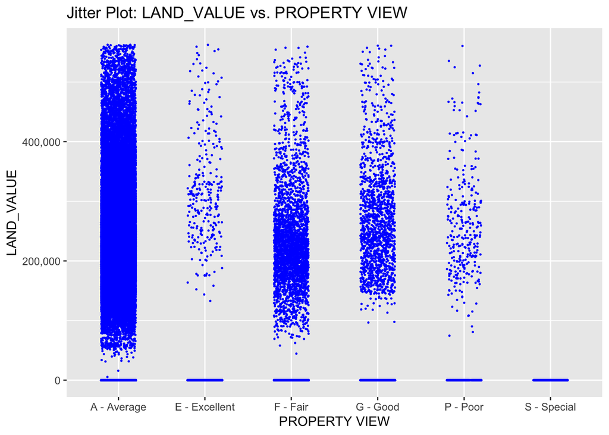

```r
jitter_prop_view_landvalue <- property_subset_clean %>%
  filter(PROP_VIEW != "Unknown") %>%
  select(LAND_VALUE, PROP_VIEW)

ggplot(jitter_prop_view_landvalue, aes(x = PROP_VIEW, y = LAND_VALUE)) +
  geom_jitter(width = 0.2, height = 0, color = "blue", size = 0.25) +
  labs(title = "Jitter Plot: LAND_VALUE vs. PROPERTY VIEW",
       x = "PROPERTY VIEW", y = "LAND_VALUE")+
    scale_y_continuous(labels = scales::comma)
```

```r
# Format y-axis labels with commas
```

### b) Scatter Plots

- We’ve used `par()` to display two scatter plots side-by-side and `plot()` to create the graphs

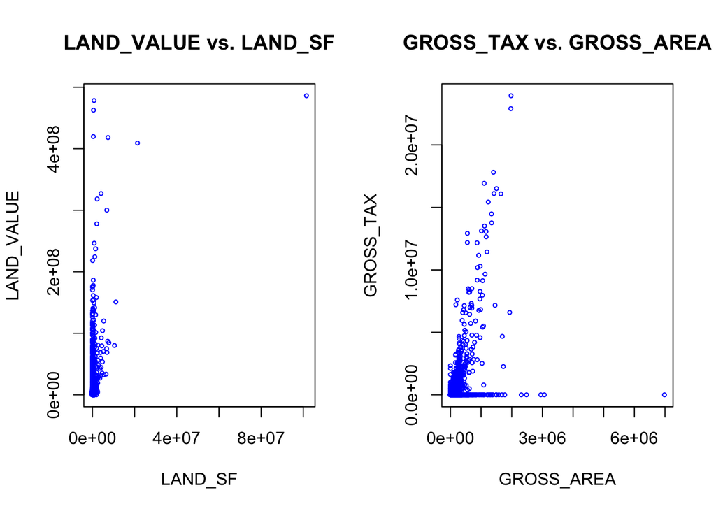

```r
# Set up the layout for multiple plots
par(mfrow = c(1, 2))  # 1x2 grid for multiple plots


# Change axis labels to non-scientific notation
options(scipen = 999)

# Scatter Plot: LAND_VALUE vs. LAND_SF
plot(property_dataset$LAND_SF, property_dataset$LAND_VALUE,
     main = "LAND_VALUE vs. LAND_SF",
     xlab = "LAND_SF", ylab = "LAND_VALUE", col = "blue",
     pch = 1,      # Change point type
     cex = 0.5)     # Change point size


# Scatter Plot: GROSS_TAX vs. GROSS_AREA
plot(property_dataset$GROSS_AREA, property_dataset$GROSS_TAX,
     main = "GROSS_TAX vs. GROSS_AREA",
     xlab = "GROSS_AREA", ylab = "GROSS_TAX", col = "blue",
     pch= 1,
     cex = 0.5
     )
```

```r
options(scipen = 0)

# Reset the layout to default
par(mfrow = c(1, 1))
```

- The scatter plot on the left shows relation between Land_value and Land sf. We can notice outliers which are distant points away from main distribution.
- The scatter plot on the right shows relation between Gross tax and Gross area and a slight positive correaltion can be observed between the two variables. We can observe outliers which are distant from the main distribution.

### Q. How can you use boxplots to detect outliers?

- In a boxplot, the box represents the interquartile range (IQR), which is the range between the first quartile (Q1) and the third quartile (Q3).
- The median is represented by a line inside the box.
- “Whiskers” extend from the box to the minimum and maximum values within a certain range.
- Points beyond the whiskers are considered potential outliers.
- `abline()` is used commonly to detect or hihglight outliers by drawing a line at 1.5 times the IQR from the quartiles.

#### i) BOXPLOT for building value

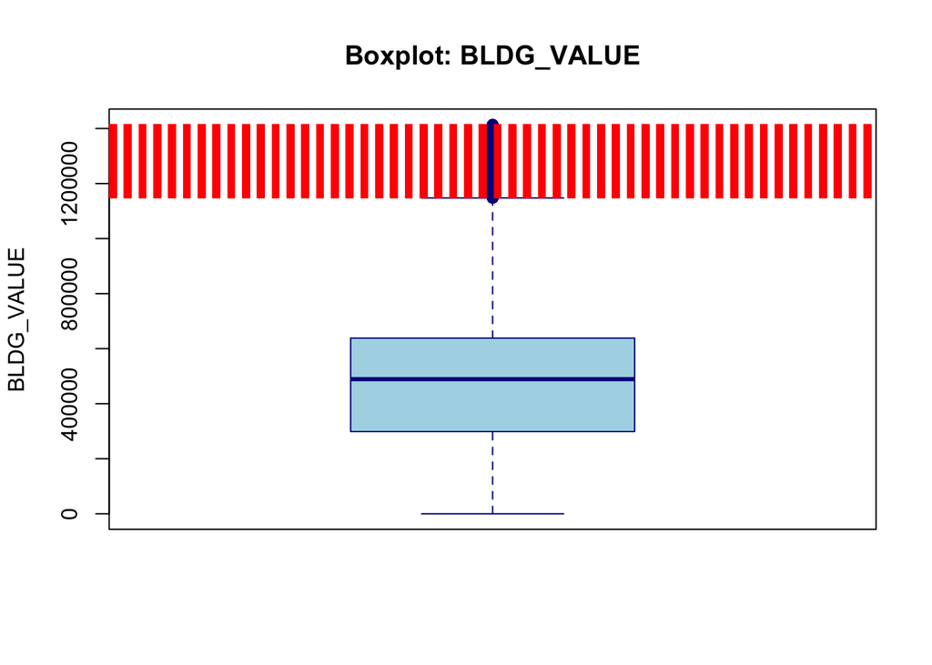

```r
boxplot(property_subset_clean$BLDG_VALUE,
        main = "Boxplot: BLDG_VALUE",
        col = "lightblue",
        border = "darkblue",
        ylab = "BLDG_VALUE")

# Calculate the threshold for outliers (you can adjust the multiplier as needed)
threshold <- 1.5  # Adjust this value based on your requirements

# Add a horizontal line to the boxplot at the threshold with a red dashed line
abline(h = boxplot.stats(property_subset_clean$BLDG_VALUE)$out, col = "red", lty = 2, lwd = 0.5)
```

- The boxplot helps visually summarize and compare the central tendency, spread, and potential outliers in **Building values**. The red line indicates outliers.

#### ii) BOXPLOT for LAND VALUE by LU

- This plot allows us to visualize the distribution of land values within different categories of the LU variable

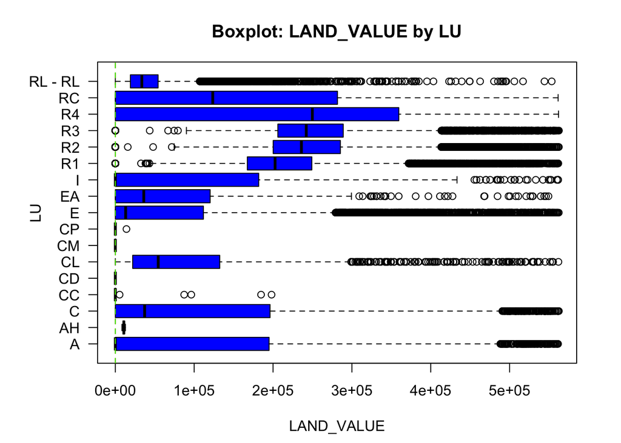

```r
options(scipen = 999)


# Adjust the margins to create more space for y-axis labels
par(mar = c(4, 5, 3, 2) + 0.5)  # c(bottom, left, top, right)

# Create the boxplot
boxplot(LAND_VALUE ~ LU, data = property_subset_clean,horizontal = TRUE,
        main = "Boxplot: LAND_VALUE by LU",
        col = "blue", ylab = "LU", las = 1)

lower_threshold <- 1.5  # Adjust this value based on your lower bound requirements
upper_threshold <- 10  # Adjust this value based on your upper bound requirements

abline(v = lower_threshold, col = "red", lty = 2)
abline(v = upper_threshold, col = "green", lty = 2)
```

```r
# Reset the margins to default after creating the plot
par(mar = c(5, 4, 4, 2) + 0.1)  # Reset to default values

options(scipen = 0)
```

- The boxplot above shows the distribution of Land values within LU’s. The values beyond the whiskers are **potential outliers**.
- Majority of the LU’s have right skew since their right whiskers are longer.

#### iii) BOXPLOT for LAND VALUE by AC Type

- This plot allows us to visualize the distribution of land values within different categories of the AC_TYPE variable
- Plotted graph using `boxplot()` and also used `abline()` for outlier detection.

[figure not shown]

```r
options(scipen = 999)

boxplot(LAND_VALUE ~ AC_TYPE, data = property_subset_clean,
        main = "Boxplot: LAND_VALUE by AC_TYPE",
        col = "lightgreen",
        border = "darkgreen",
        xlab = "AC_TYPE",
        ylab = "LAND_VALUE")

# Calculate the threshold for outliers (you can adjust the multiplier as needed)
threshold <- 1.5  # Adjust this value based on your requirements

# Add a horizontal line to the boxplot at the threshold
abline(h = boxplot.stats(property_subset_clean$LAND_VALUE)$out, col = "red", lty = 2, lwd = 0.5)
```

```r
options(scipen = 0)
```

- The boxplot helps visually summarize and compare the central tendency, spread, and potential outliers in land values for each “AC_TYPE” category.
- The Land value within **Central AC** is more skewed than **Ductless AC**.

#### iv) BOXPLOT for Gross Area by Heat Type

- This plot allows us to visualize the distribution of gross area within different categories of the HEAT_TYPE variable

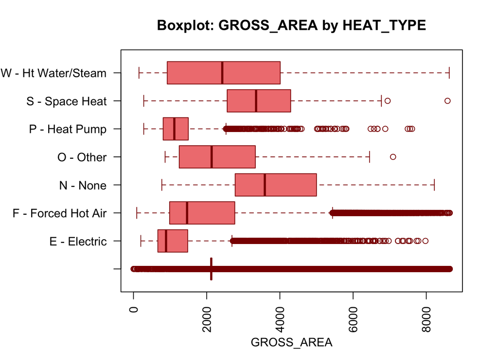

```r
# Adjust the margins to create more space for y-axis labels
par(mar = c(4, 8, 3, 2) + 0.5)  # c(bottom, left, top, right)

boxplot(GROSS_AREA ~ HEAT_TYPE, data = property_subset_clean,horizontal = TRUE,
        main = "Boxplot: GROSS_AREA by HEAT_TYPE",
        col = "lightcoral",
        border = "darkred",
        xlab = "GROSS_AREA",
        ylab = "",
        names.arg = c("Electric", "Forced", "Label3", "Label4"),  # Replace with your actual labels
        las = 2)  # Rotate x-axis labels at a 45-degree angle
```

```r
# Reset the margins to default after creating the plot
par(mar = c(5, 4, 4, 2) + 0.1)  # Reset to default values
```

- The boxplot helps visually summarize and compare the central tendency, spread, and potential outliers in **Gross area** for each **Heat_Type** category.